# M4T3 - Develop Models - Galaxy

# 1 Project Summary

We will develop several models and pick the best model using Small matrix dataset which are manually labeled with a sentiment rating for Galaxy. We will then use the best model to predict sentiment ratings of the large matrix dataset for Galaxy.

# 2 Enviroment Setup

This section contains the enviroment setup and data import steps.

```r
setwd("~/XTOL Big Data/Module 4/Task 3 - Develop Models/Samsung Analysis")
```

```
The working directory was changed to C:/Users/smele/Documents/XTOL Big Data/Module 4/Task 3 - Develop Models/Samsung Analysis inside a notebook chunk. The working directory will be reset when the chunk is finished running. Use the knitr root.dir option in the setup chunk to change the working direct…
```

```r
################
# Load packages
################
library(caret)
library(corrplot)
library(readr)
library(e1071)
library(C50)
library(kknn)
library(gbm)
library(dplyr)

#####################
# Parallel processing
#####################

library(doParallel)

# Check number of cores and workers available
detectCores()
```

```
[1] 8
```

```r
cl <- makeCluster(4)
registerDoParallel(cl)
getDoParWorkers()
```

```
[1] 4
```

## 2.1 Import Data

```r
###############
# Import data
##############

## Load training and test set
galaxy_smallmatrix<- read.csv("~/XTOL Big Data/Module 4/Task 3 - Develop Models/galaxy_smallmatrix_labeled_9d.csv", stringsAsFactors = FALSE, header=T)
galaxy_largematrix<- read.csv("~/XTOL Big Data/Module 4/Task 3 - Develop Models/galaxyLargeMatrix.csv", stringsAsFactors = FALSE, header=T)

################
# Evaluate data
################

#--- Training Set ---#
summary(galaxy_smallmatrix)
```

```
     iphone       samsunggalaxy       sonyxperia       nokialumina          htcphone             ios         googleandroid
 Min.   : 0.000   Min.   :0.00000   Min.   :0.00000   Min.   :0.000000   Min.   :  0.0000   Min.   :0.0000   Min.   :0.00000
 1st Qu.: 1.000   1st Qu.:0.00000   1st Qu.:0.00000   1st Qu.:0.000000   1st Qu.:  0.0000   1st Qu.:0.0000   1st Qu.:0.00000
 Median : 1.000   Median :0.00000   Median :0.00000   Median :0.000000   Median :  0.0000   Median :0.0000   Median :0.00000
 Mean   : 2.209   Mean   :0.07133   Mean   :0.02409   Mean   :0.002324   Mean   :  0.1375   Mean   :0.1527   Mean   :0.03973
 3rd Qu.: 1.000   3rd Qu.:0.00000   3rd Qu.:0.00000   3rd Qu.:0.000000   3rd Qu.:  0.0000   3rd Qu.:0.0000   3rd Qu.:0.00000
 Max.   :46.000   Max.   :8.00000   Max.   :8.00000   Max.   :2.000000   Max.   :479.0000   Max.   :6.0000   Max.   :6.00000
  iphonecampos      samsungcampos        sonycampos        nokiacampos          htccampos         iphonecamneg
 Min.   :  0.0000   Min.   : 0.00000   Min.   :0.000000   Min.   : 0.000000   Min.   :  0.0000   Min.   : 0.0000
 1st Qu.:  0.0000   1st Qu.: 0.00000   1st Qu.:0.000000   1st Qu.: 0.000000   1st Qu.:  0.0000   1st Qu.: 0.0000
 Median :  0.0000   Median : 0.00000   Median :0.000000   Median : 0.000000   Median :  0.0000   Median : 0.0000
 Mean   :  0.2891   Mean   : 0.05368   Mean   :0.009682   Mean   : 0.006893   Mean   :  0.1132   Mean   : 0.2345
 3rd Qu.:  0.0000   3rd Qu.: 0.00000   3rd Qu.:0.000000   3rd Qu.: 0.000000   3rd Qu.:  0.0000   3rd Qu.: 0.0000
 Max.   :156.0000   Max.   :65.00000   Max.   :8.000000   Max.   :17.000000   Max.   :156.0000   Max.   :31.0000
 samsungcamneg        sonycamneg        nokiacamneg          htccamneg        iphonecamunc     samsungcamunc
 Min.   : 0.00000   Min.   :0.000000   Min.   : 0.000000   Min.   : 0.0000   Min.   : 0.0000   Min.   : 0.00000
 1st Qu.: 0.00000   1st Qu.:0.000000   1st Qu.: 0.000000   1st Qu.: 0.0000   1st Qu.: 0.0000   1st Qu.: 0.00000
 Median : 0.00000   Median :0.000000   Median : 0.000000   Median : 0.0000   Median : 0.0000   Median : 0.00000
 Mean   : 0.05499   Mean   :0.002324   Mean   : 0.006196   Mean   : 0.0931   Mean   : 0.2539   Mean   : 0.01867
 3rd Qu.: 0.00000   3rd Qu.:0.000000   3rd Qu.: 0.000000   3rd Qu.: 0.0000   3rd Qu.: 0.0000   3rd Qu.: 0.00000
 Max.   :17.00000   Max.   :5.000000   Max.   :12.000000   Max.   :21.0000   Max.   :45.0000   Max.   :11.00000
   sonycamunc        nokiacamunc         htccamunc         iphonedispos     samsungdispos        sonydispos
 Min.   :0.000000   Min.   : 0.00000   Min.   : 0.00000   Min.   : 0.0000   Min.   : 0.00000   Min.   : 0.00000
 1st Qu.:0.000000   1st Qu.: 0.00000   1st Qu.: 0.00000   1st Qu.: 0.0000   1st Qu.: 0.00000   1st Qu.: 0.00000
 Median :0.000000   Median : 0.00000   Median : 0.00000   Median : 0.0000   Median : 0.00000   Median : 0.00000
 Mean   :0.003098   Mean   : 0.00364   Mean   : 0.04709   Mean   : 0.7165   Mean   : 0.06305   Mean   : 0.01108
 3rd Qu.:0.000000   3rd Qu.: 0.00000   3rd Qu.: 0.00000   3rd Qu.: 0.0000   3rd Qu.: 0.00000   3rd Qu.: 0.00000
 Max.   :4.000000   Max.   :10.00000   Max.   :20.00000   Max.   :66.0000   Max.   :51.00000   Max.   :32.00000
  nokiadispos          htcdispos         iphonedisneg      samsungdisneg       sonydisneg        nokiadisneg
 Min.   : 0.000000   Min.   :  0.0000   Min.   :  0.0000   Min.   : 0.0000   Min.   : 0.00000   Min.   : 0.000000
 1st Qu.: 0.000000   1st Qu.:  0.0000   1st Qu.:  0.0000   1st Qu.: 0.0000   1st Qu.: 0.00000   1st Qu.: 0.000000
 Median : 0.000000   Median :  0.0000   Median :  0.0000   Median : 0.0000   Median : 0.00000   Median : 0.000000
 Mean   : 0.009991   Mean   :  0.1579   Mean   :  0.6079   Mean   : 0.0663   Mean   : 0.01247   Mean   : 0.007978
 3rd Qu.: 0.000000   3rd Qu.:  0.0000   3rd Qu.:  0.0000   3rd Qu.: 0.0000   3rd Qu.: 0.00000   3rd Qu.: 0.000000
 Max.   :23.000000   Max.   :479.0000   Max.   :120.0000   Max.   :48.0000   Max.   :97.00000   Max.   :18.000000
   htcdisneg        iphonedisunc     samsungdisunc        sonydisunc         nokiadisunc          htcdisunc         iphoneperpos
 Min.   : 0.0000   Min.   : 0.0000   Min.   : 0.00000   Min.   : 0.000000   Min.   : 0.000000   Min.   : 0.00000   Min.   : 0.000
 1st Qu.: 0.0000   1st Qu.: 0.0000   1st Qu.: 0.00000   1st Qu.: 0.000000   1st Qu.: 0.000000   1st Qu.: 0.00000   1st Qu.: 0.000
 Median : 0.0000   Median : 0.0000   Median : 0.00000   Median : 0.000000   Median : 0.000000   Median : 0.00000   Median : 0.000
 Mean   : 0.1163   Mean   : 0.5049   Mean   : 0.02719   Mean   : 0.004492   Mean   : 0.004957   Mean   : 0.06274   Mean   : 0.603
```

[output cut: 8 more lines]

```
 Max.   :57.00000   Max.   :14.00000   Max.   :21.00000   Max.   :65.000   Max.   :33.0000   Max.   :33.00000   Max.   :28.000000
  nokiaperneg        htcperneg        iphoneperunc    samsungperunc        sonyperunc        nokiaperunc          htcperunc
 Min.   : 0.0000   Min.   : 0.0000   Min.   : 0.000   Min.   : 0.00000   Min.   :0.000000   Min.   : 0.000000   Min.   : 0.00000
 1st Qu.: 0.0000   1st Qu.: 0.0000   1st Qu.: 0.000   1st Qu.: 0.00000   1st Qu.:0.000000   1st Qu.: 0.000000   1st Qu.: 0.00000
 Median : 0.0000   Median : 0.0000   Median : 0.000   Median : 0.00000   Median :0.000000   Median : 0.000000   Median : 0.00000
 Mean   : 0.0103   Mean   : 0.1207   Mean   : 0.298   Mean   : 0.02207   Mean   :0.002169   Mean   : 0.005577   Mean   : 0.06421
 3rd Qu.: 0.0000   3rd Qu.: 0.0000   3rd Qu.: 0.000   3rd Qu.: 0.00000   3rd Qu.:0.000000   3rd Qu.: 0.000000   3rd Qu.: 0.00000
 Max.   :18.0000   Max.   :33.0000   Max.   :31.000   Max.   :31.00000   Max.   :5.000000   Max.   :13.000000   Max.   :59.00000
   iosperpos         googleperpos        iosperneg         googleperneg        iosperunc         googleperunc      galaxysentiment
 Min.   : 0.00000   Min.   : 0.00000   Min.   : 0.00000   Min.   : 0.00000   Min.   : 0.00000   Min.   : 0.00000   Min.   :0.000
 1st Qu.: 0.00000   1st Qu.: 0.00000   1st Qu.: 0.00000   1st Qu.: 0.00000   1st Qu.: 0.00000   1st Qu.: 0.00000   1st Qu.:3.000
 Median : 0.00000   Median : 0.00000   Median : 0.00000   Median : 0.00000   Median : 0.00000   Median : 0.00000   Median :5.000
 Mean   : 0.05948   Mean   : 0.03873   Mean   : 0.05786   Mean   : 0.05848   Mean   : 0.03323   Mean   : 0.01619   Mean   :3.829
 3rd Qu.: 0.00000   3rd Qu.: 0.00000   3rd Qu.: 0.00000   3rd Qu.: 0.00000   3rd Qu.: 0.00000   3rd Qu.: 0.00000   3rd Qu.:5.000
 Max.   :26.00000   Max.   :24.00000   Max.   :20.00000   Max.   :25.00000   Max.   :10.00000   Max.   :24.00000   Max.   :5.000
```

```r
str(galaxy_smallmatrix)
```

```
'data.frame':   12911 obs. of  59 variables:
 $ iphone         : int  1 1 1 0 1 2 1 1 4 1 ...
 $ samsunggalaxy  : int  0 0 1 0 0 0 0 0 0 0 ...
 $ sonyxperia     : int  0 0 0 0 0 0 0 0 0 0 ...
 $ nokialumina    : int  0 0 0 0 0 0 0 0 0 0 ...
 $ htcphone       : int  0 0 0 1 0 0 0 0 0 0 ...
 $ ios            : int  0 0 0 0 0 0 0 0 0 0 ...
 $ googleandroid  : int  0 0 0 0 0 0 0 0 0 0 ...
 $ iphonecampos   : int  0 0 1 0 0 1 0 0 0 0 ...
 $ samsungcampos  : int  0 0 1 0 0 0 0 0 0 0 ...
 $ sonycampos     : int  0 0 0 0 0 0 0 0 0 0 ...
 $ nokiacampos    : int  0 0 0 0 0 0 0 0 0 0 ...
 $ htccampos      : int  0 0 0 0 0 0 0 0 0 0 ...
 $ iphonecamneg   : int  0 0 0 0 0 0 0 0 0 0 ...
 $ samsungcamneg  : int  0 0 0 0 0 0 0 0 0 0 ...
```

[output cut: 45 more lines]

```r
head(galaxy_smallmatrix)
```

|  | iphone | samsunggalaxy | sonyxperia | nokialumina | htcphone | ios | googleandroid | iphonecampos | samsungcampos | sonycampos | nokiacampos | htccampos | iphonecamneg | samsungcamneg | sonycamneg | nokiacamneg | htccamneg | iphonecamunc | samsungcamunc | sonycamunc | nokiacamunc | htccamunc | iphonedispos | samsungdispos | sonydispos | nokiadispos | htcdispos | iphonedisneg | samsungdisneg | … |
| --- | --- | --- | --- | --- | --- | --- | --- | --- | --- | --- | --- | --- | --- | --- | --- | --- | --- | --- | --- | --- | --- | --- | --- | --- | --- | --- | --- | --- | --- | --- |
| 1 | 1 | 0 | 0 | 0 | 0 | 0 | 0 | 0 | 0 | 0 | 0 | 0 | 0 | 0 | 0 | 0 | 0 | 0 | 0 | 0 | 0 | 0 | 0 | 0 | 0 | 0 | 0 | 0 | 0 | … |
| 2 | 1 | 0 | 0 | 0 | 0 | 0 | 0 | 0 | 0 | 0 | 0 | 0 | 0 | 0 | 0 | 0 | 0 | 0 | 0 | 0 | 0 | 0 | 1 | 0 | 0 | 0 | 0 | 1 | 0 | … |
| 3 | 1 | 1 | 0 | 0 | 0 | 0 | 0 | 1 | 1 | 0 | 0 | 0 | 0 | 0 | 0 | 0 | 0 | 0 | 0 | 0 | 0 | 0 | 0 | 0 | 0 | 0 | 0 | 0 | 0 | … |
| 4 | 0 | 0 | 0 | 0 | 1 | 0 | 0 | 0 | 0 | 0 | 0 | 0 | 0 | 0 | 0 | 0 | 0 | 0 | 0 | 0 | 0 | 0 | 0 | 0 | 0 | 0 | 1 | 0 | 0 | … |
| 5 | 1 | 0 | 0 | 0 | 0 | 0 | 0 | 0 | 0 | 0 | 0 | 0 | 0 | 0 | 0 | 0 | 0 | 0 | 0 | 0 | 0 | 0 | 0 | 0 | 0 | 0 | 0 | 0 | 0 | … |
| 6 | 2 | 0 | 0 | 0 | 0 | 0 | 0 | 1 | 0 | 0 | 0 | 0 | 0 | 0 | 0 | 0 | 0 | 0 | 0 | 0 | 0 | 0 | 0 | 0 | 0 | 0 | 0 | 0 | 0 | … |

```r
tail(galaxy_smallmatrix)
```

|  | iphone | samsunggalaxy | sonyxperia | nokialumina | htcphone | ios | googleandroid | iphonecampos | samsungcampos | sonycampos | nokiacampos | htccampos | iphonecamneg | samsungcamneg | sonycamneg | nokiacamneg | htccamneg | iphonecamunc | samsungcamunc | sonycamunc | nokiacamunc | htccamunc | iphonedispos | samsungdispos | sonydispos | nokiadispos | htcdispos | iphonedisneg | samsungdisneg | … |
| --- | --- | --- | --- | --- | --- | --- | --- | --- | --- | --- | --- | --- | --- | --- | --- | --- | --- | --- | --- | --- | --- | --- | --- | --- | --- | --- | --- | --- | --- | --- |
| 12906 | 2 | 1 | 1 | 0 | 1 | 0 | 0 | 0 | 0 | 0 | 0 | 0 | 0 | 0 | 0 | 0 | 0 | 0 | 0 | 0 | 0 | 0 | 0 | 0 | 0 | 0 | 0 | 0 | 0 | … |
| 12907 | 1 | 0 | 0 | 0 | 0 | 0 | 0 | 0 | 0 | 0 | 0 | 0 | 0 | 0 | 0 | 0 | 0 | 0 | 0 | 0 | 0 | 0 | 0 | 0 | 0 | 0 | 0 | 0 | 0 | … |
| 12908 | 1 | 0 | 0 | 0 | 0 | 0 | 0 | 7 | 0 | 0 | 0 | 0 | 0 | 0 | 0 | 0 | 0 | 0 | 0 | 0 | 0 | 0 | 8 | 0 | 0 | 0 | 0 | 0 | 0 | … |
| 12909 | 1 | 0 | 0 | 0 | 0 | 0 | 0 | 1 | 0 | 0 | 0 | 0 | 0 | 0 | 0 | 0 | 0 | 0 | 0 | 0 | 0 | 0 | 0 | 0 | 0 | 0 | 0 | 0 | 0 | … |
| 12910 | 1 | 0 | 0 | 0 | 0 | 0 | 0 | 0 | 0 | 0 | 0 | 0 | 0 | 0 | 0 | 0 | 0 | 0 | 0 | 0 | 0 | 0 | 0 | 0 | 0 | 0 | 0 | 0 | 0 | … |
| 12911 | 1 | 0 | 0 | 0 | 0 | 0 | 0 | 0 | 0 | 0 | 0 | 0 | 0 | 0 | 0 | 0 | 0 | 0 | 0 | 0 | 0 | 0 | 0 | 0 | 0 | 0 | 0 | 0 | 0 | … |

```r
table(galaxy_smallmatrix$galaxysentiment)
```

```
   0    1    2    3    4    5
1696  382  450 1175 1417 7791
```

```r
# check for missing values
is.na(galaxy_smallmatrix)
```

[output not shown]

[output cut: 1006 more lines]

```r
any(is.na(galaxy_smallmatrix))
```

```
[1] FALSE
```

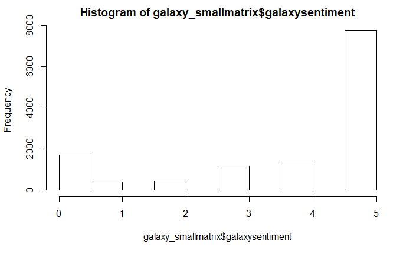

```r
# plot
hist(galaxy_smallmatrix$galaxysentiment)
```

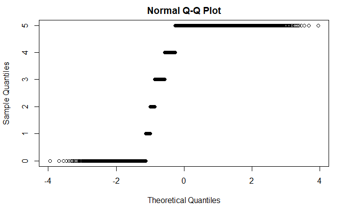

```r
qqnorm(galaxy_smallmatrix$galaxysentiment)
```

```r
#--- Prediction Set ---#
summary(galaxy_largematrix)
```

```
       id            iphone        samsunggalaxy       sonyxperia        nokialumina           htcphone            ios
 Min.   :    0   Min.   : 0.0000   Min.   : 0.0000   Min.   : 0.00000   Min.   :0.0000000   Min.   :0.00000   Min.   : 0.0000
 1st Qu.: 8056   1st Qu.: 0.0000   1st Qu.: 0.0000   1st Qu.: 0.00000   1st Qu.:0.0000000   1st Qu.:0.00000   1st Qu.: 0.0000
 Median :16112   Median : 1.0000   Median : 0.0000   Median : 0.00000   Median :0.0000000   Median :0.00000   Median : 0.0000
 Mean   :16112   Mean   : 0.8664   Mean   : 0.1445   Mean   : 0.05592   Mean   :0.0002482   Mean   :0.07736   Mean   : 0.4561
 3rd Qu.:24169   3rd Qu.: 1.0000   3rd Qu.: 0.0000   3rd Qu.: 0.00000   3rd Qu.:0.0000000   3rd Qu.:0.00000   3rd Qu.: 1.0000
 Max.   :32225   Max.   :40.0000   Max.   :29.0000   Max.   :21.00000   Max.   :1.0000000   Max.   :9.00000   Max.   :78.0000
 googleandroid      iphonecampos     samsungcampos        sonycampos        nokiacampos          htccampos         iphonecamneg
 Min.   : 0.0000   Min.   : 0.0000   Min.   : 0.00000   Min.   : 0.00000   Min.   : 0.000000   Min.   : 0.00000   Min.   : 0.000
 1st Qu.: 0.0000   1st Qu.: 0.0000   1st Qu.: 0.00000   1st Qu.: 0.00000   1st Qu.: 0.000000   1st Qu.: 0.00000   1st Qu.: 0.000
 Median : 0.0000   Median : 0.0000   Median : 0.00000   Median : 0.00000   Median : 0.000000   Median : 0.00000   Median : 0.000
 Mean   : 0.1232   Mean   : 0.2255   Mean   : 0.05449   Mean   : 0.03485   Mean   : 0.001086   Mean   : 0.05852   Mean   : 0.122
 3rd Qu.: 0.0000   3rd Qu.: 0.0000   3rd Qu.: 0.00000   3rd Qu.: 0.00000   3rd Qu.: 0.000000   3rd Qu.: 0.00000   3rd Qu.: 0.000
 Max.   :16.0000   Max.   :72.0000   Max.   :43.00000   Max.   :43.00000   Max.   :27.000000   Max.   :43.00000   Max.   :29.000
 samsungcamneg       sonycamneg       nokiacamneg         htccamneg         iphonecamunc     samsungcamunc        sonycamunc
 Min.   :0.00000   Min.   :0.00000   Min.   :0.00e+00   Min.   : 0.00000   Min.   : 0.0000   Min.   : 0.00000   Min.   : 0.00000
 1st Qu.:0.00000   1st Qu.:0.00000   1st Qu.:0.00e+00   1st Qu.: 0.00000   1st Qu.: 0.0000   1st Qu.: 0.00000   1st Qu.: 0.00000
 Median :0.00000   Median :0.00000   Median :0.00e+00   Median : 0.00000   Median : 0.0000   Median : 0.00000   Median : 0.00000
 Mean   :0.02687   Mean   :0.01902   Mean   :4.03e-04   Mean   : 0.04062   Mean   : 0.1313   Mean   : 0.02824   Mean   : 0.01784
 3rd Qu.:0.00000   3rd Qu.:0.00000   3rd Qu.:0.00e+00   3rd Qu.: 0.00000   3rd Qu.: 0.0000   3rd Qu.: 0.00000   3rd Qu.: 0.00000
 Max.   :9.00000   Max.   :8.00000   Max.   :1.10e+01   Max.   :11.00000   Max.   :87.0000   Max.   :20.00000   Max.   :20.00000
  nokiacamunc         htccamunc         iphonedispos     samsungdispos        sonydispos        nokiadispos
 Min.   :0.00e+00   Min.   : 0.00000   Min.   : 0.0000   Min.   : 0.00000   Min.   : 0.00000   Min.   :0.000000
 1st Qu.:0.00e+00   1st Qu.: 0.00000   1st Qu.: 0.0000   1st Qu.: 0.00000   1st Qu.: 0.00000   1st Qu.:0.000000
 Median :0.00e+00   Median : 0.00000   Median : 0.0000   Median : 0.00000   Median : 0.00000   Median :0.000000
 Mean   :4.96e-04   Mean   : 0.03671   Mean   : 0.4049   Mean   : 0.07941   Mean   : 0.04434   Mean   :0.000372
 3rd Qu.:0.00e+00   3rd Qu.: 0.00000   3rd Qu.: 0.0000   3rd Qu.: 0.00000   3rd Qu.: 0.00000   3rd Qu.:0.000000
 Max.   :1.00e+01   Max.   :20.00000   Max.   :93.0000   Max.   :57.00000   Max.   :53.00000   Max.   :7.000000
   htcdispos         iphonedisneg     samsungdisneg        sonydisneg        nokiadisneg          htcdisneg
 Min.   : 0.00000   Min.   : 0.0000   Min.   : 0.00000   Min.   : 0.00000   Min.   :0.0000000   Min.   : 0.00000
 1st Qu.: 0.00000   1st Qu.: 0.0000   1st Qu.: 0.00000   1st Qu.: 0.00000   1st Qu.:0.0000000   1st Qu.: 0.00000
 Median : 0.00000   Median : 0.0000   Median : 0.00000   Median : 0.00000   Median :0.0000000   Median : 0.00000
 Mean   : 0.07547   Mean   : 0.3262   Mean   : 0.04977   Mean   : 0.03569   Mean   :0.0001241   Mean   : 0.05576
 3rd Qu.: 0.00000   3rd Qu.: 0.0000   3rd Qu.: 0.00000   3rd Qu.: 0.00000   3rd Qu.:0.0000000   3rd Qu.: 0.00000
 Max.   :57.00000   Max.   :55.0000   Max.   :22.00000   Max.   :22.00000   Max.   :3.0000000   Max.   :22.00000
  iphonedisunc     samsungdisunc        sonydisunc        nokiadisunc         htcdisunc         iphoneperpos     samsungperpos
 Min.   : 0.0000   Min.   : 0.00000   Min.   : 0.00000   Min.   :0.000000   Min.   : 0.00000   Min.   : 0.0000   Min.   : 0.00000
 1st Qu.: 0.0000   1st Qu.: 0.00000   1st Qu.: 0.00000   1st Qu.:0.000000   1st Qu.: 0.00000   1st Qu.: 0.0000   1st Qu.: 0.00000
 Median : 0.0000   Median : 0.00000   Median : 0.00000   Median :0.000000   Median : 0.00000   Median : 0.0000   Median : 0.00000
 Mean   : 0.2994   Mean   : 0.05049   Mean   : 0.02929   Mean   :0.000217   Mean   : 0.05319   Mean   : 0.5071   Mean   : 0.09635
```

[output cut: 8 more lines]

```
 Max.   :64.0000   Max.   :21.000000   Max.   :64.0000   Max.   :50.0000   Max.   :27.00000   Max.   :26.00000   Max.   :9.000000
   htcperneg        iphoneperunc     samsungperunc        sonyperunc        nokiaperunc          htcperunc          iosperpos
 Min.   : 0.0000   Min.   : 0.0000   Min.   : 0.00000   Min.   : 0.00000   Min.   : 0.000000   Min.   : 0.00000   Min.   : 0.000
 1st Qu.: 0.0000   1st Qu.: 0.0000   1st Qu.: 0.00000   1st Qu.: 0.00000   1st Qu.: 0.000000   1st Qu.: 0.00000   1st Qu.: 0.000
 Median : 0.0000   Median : 0.0000   Median : 0.00000   Median : 0.00000   Median : 0.000000   Median : 0.00000   Median : 0.000
 Mean   : 0.1066   Mean   : 0.3071   Mean   : 0.05055   Mean   : 0.02833   Mean   : 0.002762   Mean   : 0.06709   Mean   : 0.248
 3rd Qu.: 0.0000   3rd Qu.: 0.0000   3rd Qu.: 0.00000   3rd Qu.: 0.00000   3rd Qu.: 0.000000   3rd Qu.: 0.00000   3rd Qu.: 0.000
 Max.   :26.0000   Max.   :55.0000   Max.   :29.00000   Max.   :14.00000   Max.   :20.000000   Max.   :15.00000   Max.   :50.000
  googleperpos        iosperneg         googleperneg        iosperunc        googleperunc      galaxysentiment
 Min.   : 0.00000   Min.   :  0.0000   Min.   : 0.00000   Min.   : 0.0000   Min.   : 0.00000   Mode:logical
 1st Qu.: 0.00000   1st Qu.:  0.0000   1st Qu.: 0.00000   1st Qu.: 0.0000   1st Qu.: 0.00000   NA's:32226
 Median : 0.00000   Median :  0.0000   Median : 0.00000   Median : 0.0000   Median : 0.00000
 Mean   : 0.09551   Mean   :  0.1905   Mean   : 0.08987   Mean   : 0.1613   Mean   : 0.07634
 3rd Qu.: 0.00000   3rd Qu.:  0.0000   3rd Qu.: 0.00000   3rd Qu.: 0.0000   3rd Qu.: 0.00000
 Max.   :46.00000   Max.   :110.0000   Max.   :34.00000   Max.   :61.0000   Max.   :40.00000
```

```r
str(galaxy_largematrix)
```

```
'data.frame':   32226 obs. of  60 variables:
 $ id             : int  0 1 2 3 4 5 6 7 8 9 ...
 $ iphone         : int  0 0 0 0 0 0 0 0 0 0 ...
 $ samsunggalaxy  : int  0 0 0 0 0 0 0 0 0 0 ...
 $ sonyxperia     : int  0 0 0 0 0 0 0 0 0 0 ...
 $ nokialumina    : int  0 0 0 0 0 0 0 0 0 0 ...
 $ htcphone       : int  0 0 0 0 0 0 0 0 0 0 ...
 $ ios            : int  0 0 0 0 0 0 0 0 0 0 ...
 $ googleandroid  : int  0 0 0 0 0 0 0 0 0 0 ...
 $ iphonecampos   : int  0 0 0 0 0 0 0 0 0 0 ...
 $ samsungcampos  : int  0 0 0 0 0 0 0 0 0 0 ...
 $ sonycampos     : int  0 0 0 0 0 0 0 0 0 0 ...
 $ nokiacampos    : int  0 0 0 0 0 0 0 0 0 0 ...
 $ htccampos      : int  0 0 0 0 0 0 0 0 0 0 ...
 $ iphonecamneg   : int  0 0 0 0 0 0 0 0 0 0 ...
```

[output cut: 46 more lines]

```r
head(galaxy_largematrix)
```

|  | id | iphone | samsunggalaxy | sonyxperia | nokialumina | htcphone | ios | googleandroid | iphonecampos | samsungcampos | sonycampos | nokiacampos | htccampos | iphonecamneg | samsungcamneg | sonycamneg | nokiacamneg | htccamneg | iphonecamunc | samsungcamunc | sonycamunc | nokiacamunc | htccamunc | iphonedispos | samsungdispos | sonydispos | nokiadispos | htcdispos | iphonedisneg | … |
| --- | --- | --- | --- | --- | --- | --- | --- | --- | --- | --- | --- | --- | --- | --- | --- | --- | --- | --- | --- | --- | --- | --- | --- | --- | --- | --- | --- | --- | --- | --- |
| 1 | 0 | 0 | 0 | 0 | 0 | 0 | 0 | 0 | 0 | 0 | 0 | 0 | 0 | 0 | 0 | 0 | 0 | 0 | 0 | 0 | 0 | 0 | 0 | 0 | 0 | 0 | 0 | 0 | 0 | … |
| 2 | 1 | 0 | 0 | 0 | 0 | 0 | 0 | 0 | 0 | 0 | 0 | 0 | 0 | 0 | 0 | 0 | 0 | 0 | 0 | 0 | 0 | 0 | 0 | 0 | 0 | 0 | 0 | 0 | 0 | … |
| 3 | 2 | 0 | 0 | 0 | 0 | 0 | 0 | 0 | 0 | 0 | 0 | 0 | 0 | 0 | 0 | 0 | 0 | 0 | 0 | 0 | 0 | 0 | 0 | 0 | 0 | 0 | 0 | 0 | 0 | … |
| 4 | 3 | 0 | 0 | 0 | 0 | 0 | 0 | 0 | 0 | 0 | 0 | 0 | 0 | 0 | 0 | 0 | 0 | 0 | 0 | 0 | 0 | 0 | 0 | 0 | 0 | 0 | 0 | 0 | 0 | … |
| 5 | 4 | 0 | 0 | 0 | 0 | 0 | 0 | 0 | 0 | 0 | 0 | 0 | 0 | 0 | 0 | 0 | 0 | 0 | 0 | 0 | 0 | 0 | 0 | 0 | 0 | 0 | 0 | 0 | 0 | … |
| 6 | 5 | 0 | 0 | 0 | 0 | 0 | 0 | 0 | 0 | 0 | 0 | 0 | 0 | 0 | 0 | 0 | 0 | 0 | 0 | 0 | 0 | 0 | 0 | 0 | 0 | 0 | 0 | 0 | 0 | … |

```r
tail(galaxy_largematrix)
```

|  | id | iphone | samsunggalaxy | sonyxperia | nokialumina | htcphone | ios | googleandroid | iphonecampos | samsungcampos | sonycampos | nokiacampos | htccampos | iphonecamneg | samsungcamneg | sonycamneg | nokiacamneg | htccamneg | iphonecamunc | samsungcamunc | sonycamunc | nokiacamunc | htccamunc | iphonedispos | samsungdispos | sonydispos | nokiadispos | htcdispos | iphonedisneg | … |
| --- | --- | --- | --- | --- | --- | --- | --- | --- | --- | --- | --- | --- | --- | --- | --- | --- | --- | --- | --- | --- | --- | --- | --- | --- | --- | --- | --- | --- | --- | --- |
| 32221 | 32220 | 0 | 0 | 0 | 0 | 0 | 0 | 0 | 0 | 0 | 0 | 0 | 0 | 0 | 0 | 0 | 0 | 0 | 0 | 0 | 0 | 0 | 0 | 0 | 0 | 0 | 0 | 0 | 0 | … |
| 32222 | 32221 | 0 | 0 | 0 | 0 | 0 | 0 | 0 | 0 | 0 | 0 | 0 | 0 | 0 | 0 | 0 | 0 | 0 | 0 | 0 | 0 | 0 | 0 | 0 | 0 | 0 | 0 | 0 | 0 | … |
| 32223 | 32222 | 0 | 0 | 0 | 0 | 0 | 0 | 0 | 0 | 0 | 0 | 0 | 0 | 0 | 0 | 0 | 0 | 0 | 0 | 0 | 0 | 0 | 0 | 0 | 0 | 0 | 0 | 0 | 0 | … |
| 32224 | 32223 | 0 | 0 | 0 | 0 | 0 | 0 | 0 | 0 | 0 | 0 | 0 | 0 | 0 | 0 | 0 | 0 | 0 | 0 | 0 | 0 | 0 | 0 | 0 | 0 | 0 | 0 | 0 | 0 | … |
| 32225 | 32224 | 0 | 0 | 0 | 0 | 0 | 0 | 0 | 0 | 0 | 0 | 0 | 0 | 0 | 0 | 0 | 0 | 0 | 0 | 0 | 0 | 0 | 0 | 0 | 0 | 0 | 0 | 0 | 0 | … |
| 32226 | 32225 | 0 | 0 | 0 | 0 | 0 | 0 | 0 | 0 | 0 | 0 | 0 | 0 | 0 | 0 | 0 | 0 | 0 | 0 | 0 | 0 | 0 | 0 | 0 | 0 | 0 | 0 | 0 | 0 | … |

```r
# check for missing values
is.na(galaxy_largematrix)
```

[output not shown]

[output cut: 988 more lines]

```r
any(is.na(galaxy_largematrix))
```

```
[1] TRUE
```

# 3 Pre-processing

```r
#############
# Preprocess
#############

#--- Training and test set ---#

# change variable types
galaxy_smallmatrix$galaxysentiment <- as.factor(galaxy_smallmatrix$galaxysentiment)
# normalize
preprocessParamsg <- preProcess(galaxy_smallmatrix[,1:58], method = c("center", "scale"))
print(preprocessParamsg)
```

```
Created from 12911 samples and 58 variables

Pre-processing:
  - centered (58)
  - ignored (0)
  - scaled (58)
```

```r
galaxy_smallmatrix_N <- predict(preprocessParamsg, galaxy_smallmatrix)
str(galaxy_smallmatrix_N)
```

```
'data.frame':   12911 obs. of  59 variables:
 $ iphone         : num  -0.199 -0.199 -0.199 -0.364 -0.199 ...
 $ samsunggalaxy  : num  -0.254 -0.254 3.302 -0.254 -0.254 ...
 $ sonyxperia     : num  -0.14 -0.14 -0.14 -0.14 -0.14 ...
 $ nokialumina    : num  -0.0453 -0.0453 -0.0453 -0.0453 -0.0453 ...
 $ htcphone       : num  -0.0325 -0.0325 -0.0325 0.2037 -0.0325 ...
 $ ios            : num  -0.182 -0.182 -0.182 -0.182 -0.182 ...
 $ googleandroid  : num  -0.156 -0.156 -0.156 -0.156 -0.156 ...
 $ iphonecampos   : num  -0.132 -0.132 0.324 -0.132 -0.132 ...
 $ samsungcampos  : num  -0.0754 -0.0754 1.3288 -0.0754 -0.0754 ...
 $ sonycampos     : num  -0.0606 -0.0606 -0.0606 -0.0606 -0.0606 ...
 $ nokiacampos    : num  -0.0302 -0.0302 -0.0302 -0.0302 -0.0302 ...
 $ htccampos      : num  -0.0706 -0.0706 -0.0706 -0.0706 -0.0706 ...
 $ iphonecamneg   : num  -0.246 -0.246 -0.246 -0.246 -0.246 ...
 $ samsungcamneg  : num  -0.103 -0.103 -0.103 -0.103 -0.103 ...
```

[output cut: 45 more lines]

```r
#--- Prediction set ---#

# drop ID variable
galaxy_largematrix$id<- NULL
# Add a variable
galaxy_largematrix$galaxysentiment <- as.factor(galaxy_largematrix$galaxysentiment)
# normalize
galaxy_largematrix_N <- predict(preprocessParamsg, galaxy_largematrix)
str(galaxy_largematrix_N)
```

```
'data.frame':   32226 obs. of  59 variables:
 $ iphone         : num  -0.364 -0.364 -0.364 -0.364 -0.364 ...
 $ samsunggalaxy  : num  -0.254 -0.254 -0.254 -0.254 -0.254 ...
 $ sonyxperia     : num  -0.14 -0.14 -0.14 -0.14 -0.14 ...
 $ nokialumina    : num  -0.0453 -0.0453 -0.0453 -0.0453 -0.0453 ...
 $ htcphone       : num  -0.0325 -0.0325 -0.0325 -0.0325 -0.0325 ...
 $ ios            : num  -0.182 -0.182 -0.182 -0.182 -0.182 ...
 $ googleandroid  : num  -0.156 -0.156 -0.156 -0.156 -0.156 ...
 $ iphonecampos   : num  -0.132 -0.132 -0.132 -0.132 -0.132 ...
 $ samsungcampos  : num  -0.0754 -0.0754 -0.0754 -0.0754 -0.0754 ...
 $ sonycampos     : num  -0.0606 -0.0606 -0.0606 -0.0606 -0.0606 ...
 $ nokiacampos    : num  -0.0302 -0.0302 -0.0302 -0.0302 -0.0302 ...
 $ htccampos      : num  -0.0706 -0.0706 -0.0706 -0.0706 -0.0706 ...
 $ iphonecamneg   : num  -0.246 -0.246 -0.246 -0.246 -0.246 ...
 $ samsungcamneg  : num  -0.103 -0.103 -0.103 -0.103 -0.103 ...
```

[output cut: 45 more lines]

```r
##################
# Train/test sets
##################

# set random seed
set.seed(123)
# create the training partition that is 70% of total obs
inTrainingg <- createDataPartition(galaxy_smallmatrix_N$galaxysentiment, p=0.7, list=FALSE)
# create training/testing dataset
gtrainSetN <- galaxy_smallmatrix_N[inTrainingg,]
gtestSetN <- galaxy_smallmatrix_N[-inTrainingg,]

# verify number of obs
nrow(gtrainSetN)
```

```
[1] 9040
```

```r
nrow(gtestSetN)
```

```
[1] 3871
```

```r
################
# Train control
################

# set 5 fold cross validation
fitControl <- trainControl(method = "cv", number = 5)
```

# 4 Train Models

Five algorithms will be tested to determine the best fit in terms of Kappa and accuracy.

## 4.1 Decision Tree C5.0 Model

```r
## ------- Decision Tree C5.0 ------- ##
# set random seed
set.seed(123)
# train/fit
C5.0_Fitg <- train(galaxysentiment~., data=gtrainSetN, method="C5.0", trControl=fitControl, metric = "Kappa", tuneLength=5)
C5.0_Fitg
```

```
C5.0

9040 samples
  58 predictor
   6 classes: '0', '1', '2', '3', '4', '5'

No pre-processing
Resampling: Cross-Validated (5 fold)
Summary of sample sizes: 7232, 7232, 7232, 7232, 7232
Resampling results across tuning parameters:

  model  winnow  trials  Accuracy   Kappa
  rules  FALSE    1      0.7641593  0.5269740
  rules  FALSE   10      0.7522124  0.5020142
  rules  FALSE   20      0.7522124  0.5020142
  rules  FALSE   30      0.7522124  0.5020142
  rules  FALSE   40      0.7522124  0.5020142
  rules   TRUE    1      0.7627212  0.5246687
  rules   TRUE   10      0.7522124  0.5013408
  rules   TRUE   20      0.7522124  0.5013408
  rules   TRUE   30      0.7522124  0.5013408
  rules   TRUE   40      0.7522124  0.5013408
  tree   FALSE    1      0.7626106  0.5236952
  tree   FALSE   10      0.7542035  0.5067763
  tree   FALSE   20      0.7542035  0.5067763
  tree   FALSE   30      0.7542035  0.5067763
  tree   FALSE   40      0.7542035  0.5067763
  tree    TRUE    1      0.7626106  0.5251038
  tree    TRUE   10      0.7522124  0.5054784
  tree    TRUE   20      0.7522124  0.5054784
  tree    TRUE   30      0.7522124  0.5054784
  tree    TRUE   40      0.7522124  0.5054784

Kappa was used to select the optimal model using the largest value.
The final values used for the model were trials = 1, model = rules and winnow = FALSE.
```

```r
### Save model ###

saveRDS(C5.0_Fitg, "C5.0_Fitg.rds")
C5.0_Fitg <- readRDS("C5.0_Fitg.rds")

### C5.0 Prediction ###

# predict with C5.0
C5.0_Predg <- predict(C5.0_Fitg, gtestSetN)
C5.0_Predg
```

```
   [1] 5 3 5 5 5 0 5 5 3 5 0 5 5 5 5 5 5 5 5 5 5 5 5 5 5 5 5 5 5 5 5 0 5 0 5 5 0 4 3 5 5 4 5 5 0 5 5 5 0 5 5 5 5 0 5 5 5 5 5 5 5 5 5
  [64] 0 5 5 5 5 5 5 5 5 5 5 5 5 5 5 5 5 5 5 5 5 5 5 5 5 5 5 5 3 5 5 5 3 0 5 5 5 5 0 5 5 5 0 3 5 5 5 5 5 5 5 5 5 5 5 5 5 0 5 5 0 5 5
 [127] 5 5 0 5 5 5 3 5 5 5 5 0 5 5 5 0 5 5 5 5 5 5 3 5 5 5 5 4 5 5 3 5 5 5 5 5 5 5 0 5 5 5 5 5 5 5 5 4 5 5 5 5 5 5 5 5 3 5 0 3 5 5 5
 [190] 5 5 5 5 5 5 5 5 5 5 5 5 5 5 5 5 0 4 5 5 5 5 5 5 0 5 5 5 0 5 0 3 5 0 3 5 5 5 5 5 5 5 5 5 5 5 5 4 5 0 0 5 5 5 5 5 5 5 5 0 5 5 5
 [253] 5 5 3 0 5 0 5 5 0 5 0 5 5 5 5 0 0 0 5 5 5 5 5 3 5 5 5 0 5 5 4 5 5 5 2 5 5 5 4 3 3 5 5 5 5 5 3 5 5 5 5 5 5 3 5 5 3 5 0 0 5 0 0
 [316] 5 5 5 5 5 5 3 5 5 5 5 3 5 4 5 5 5 5 5 3 5 5 5 4 5 5 5 5 4 5 5 5 5 5 5 0 4 5 5 5 5 5 0 5 5 0 5 3 5 5 5 5 5 5 5 5 4 5 5 0 5 5 0
 [379] 5 5 5 5 0 5 0 5 5 5 5 5 5 5 5 5 5 5 5 5 5 5 5 5 5 5 5 3 5 5 5 5 5 5 3 5 3 5 5 5 5 5 5 5 4 5 5 5 5 5 5 5 5 5 5 5 5 5 5 5 5 5 5
 [442] 5 5 5 5 5 5 5 5 5 5 5 5 5 5 5 5 5 5 0 5 5 0 5 3 0 0 5 4 5 5 5 5 5 5 0 5 5 5 5 5 5 5 5 5 5 5 5 5 5 5 5 5 5 5 5 5 5 5 5 5 5 5 5
 [505] 5 5 5 5 5 5 5 5 5 5 5 4 0 5 5 0 3 0 5 5 5 4 5 5 5 5 5 0 0 5 5 5 5 5 0 5 5 5 5 5 5 5 5 5 0 5 5 0 5 5 5 5 5 5 5 5 5 0 5 5 5 5 5
 [568] 5 5 5 4 0 5 0 5 5 5 5 5 4 5 5 5 5 5 5 5 5 5 5 5 5 5 5 5 5 5 5 3 5 5 5 5 4 5 5 0 3 0 3 5 3 5 3 5 5 5 5 5 5 5 5 5 5 5 0 5 5 3 5
 [631] 5 5 5 5 5 5 5 5 5 3 5 5 5 5 5 5 5 5 5 5 5 5 4 5 0 5 5 5 5 5 5 3 5 0 5 5 0 5 4 5 5 5 5 5 5 5 5 5 5 5 5 0 4 5 0 0 5 5 5 3 3 5 5
 [694] 0 0 5 5 5 5 5 5 5 3 5 5 5 5 5 5 5 5 5 5 5 0 5 3 5 5 0 5 5 5 5 5 5 5 0 5 5 5 5 5 0 5 5 3 5 5 5 5 5 5 5 0 4 5 4 5 5 5 5 5 5 5 5
 [757] 5 5 5 5 5 5 5 5 5 0 5 5 5 5 5 5 5 5 5 5 5 3 5 4 3 5 3 5 5 5 4 5 5 5 5 0 5 5 5 5 5 3 5 5 5 5 5 5 5 3 5 5 5 5 3 5 5 5 5 5 5 5 0
 [820] 5 5 5 5 5 0 5 0 5 5 5 5 5 5 5 5 5 5 5 5 0 5 5 0 5 5 5 5 0 5 5 5 5 0 0 5 0 5 5 5 0 5 5 5 5 5 5 5 5 5 0 4 5 5 5 3 5 5 5 5 2 5 5
 [883] 5 5 5 4 5 5 5 5 5 5 5 5 5 5 5 5 5 5 5 5 5 4 5 5 5 5 5 5 5 5 4 5 5 5 3 5 5 5 5 5 5 3 5 5 5 5 5 5 5 5 3 5 5 0 5 5 4 5 5 3 3 5 5
```

[output cut: 48 more lines]

```r
#summarize predictions
summary(C5.0_Predg)
```

```
   0    1    2    3    4    5
 396    0   18  243  138 3076
```

```r
# performance measurement
postResample(C5.0_Predg, gtestSetN$galaxysentiment)
```

```
 Accuracy     Kappa
0.7675019 0.5322522
```

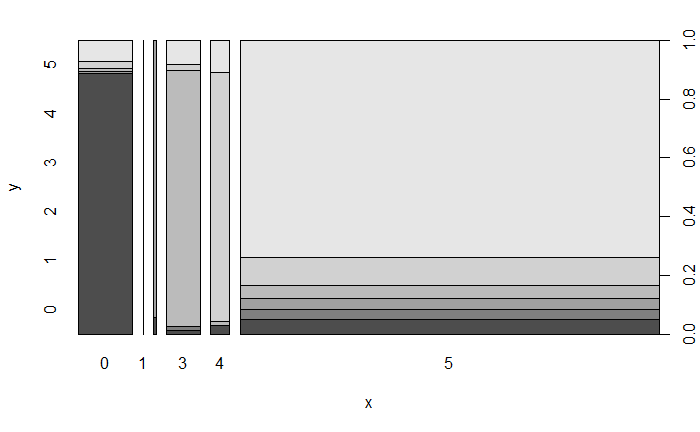

```r
# plot
plot(C5.0_Predg,gtestSetN$galaxysentiment)
```

```r
#calculate confusion Matrix
options(max.print=10000)
gcmC5.0 <-confusionMatrix(C5.0_Predg,gtestSetN$galaxysentiment, mode="everything")
gcmC5.0
```

```
Confusion Matrix and Statistics

          Reference
Prediction    0    1    2    3    4    5
         0  351    0    3    4   10   28
         1    0    0    0    0    0    0
         2    1    0   17    0    0    0
         3    3    3    0  212    5   20
         4    4    0    0    2  117   15
         5  149  111  115  134  293 2274

Overall Statistics

               Accuracy : 0.7675
                 95% CI : (0.7539, 0.7807)
    No Information Rate : 0.6037
    P-Value [Acc > NIR] : < 2.2e-16

                  Kappa : 0.5323

 Mcnemar's Test P-Value : NA

Statistics by Class:

                     Class: 0 Class: 1 Class: 2 Class: 3 Class: 4 Class: 5
Sensitivity           0.69094  0.00000 0.125926  0.60227  0.27529   0.9730
Specificity           0.98662  1.00000 0.999732  0.99119  0.99391   0.4772
Pos Pred Value        0.88636      NaN 0.944444  0.87243  0.84783   0.7393
Neg Pred Value        0.95482  0.97055 0.969375  0.96141  0.91749   0.9208
Precision             0.88636       NA 0.944444  0.87243  0.84783   0.7393
Recall                0.69094  0.00000 0.125926  0.60227  0.27529   0.9730
F1                    0.77655       NA 0.222222  0.71261  0.41563   0.8402
Prevalence            0.13123  0.02945 0.034875  0.09093  0.10979   0.6037
Detection Rate        0.09067  0.00000 0.004392  0.05477  0.03022   0.5874
Detection Prevalence  0.10230  0.00000 0.004650  0.06277  0.03565   0.7946
Balanced Accuracy     0.83878  0.50000 0.562829  0.79673  0.63460   0.7251
```

## 4.2 Random Forest Model

```r
## ------- random forest ------- ##

# set random seed
set.seed(123)
# train/fit
rf_Fitg <- train(galaxysentiment~., data=gtrainSetN, method="rf", trControl=fitControl, metric = "Kappa",tuneLength=5)
rf_Fitg
```

```
Random Forest

9040 samples
  58 predictor
   6 classes: '0', '1', '2', '3', '4', '5'

No pre-processing
Resampling: Cross-Validated (5 fold)
Summary of sample sizes: 7232, 7232, 7232, 7232, 7232
Resampling results across tuning parameters:

  mtry  Accuracy   Kappa
   2    0.7056416  0.3584158
  16    0.7657080  0.5308090
  30    0.7621681  0.5272669
  44    0.7595133  0.5246202
  58    0.7544248  0.5169769

Kappa was used to select the optimal model using the largest value.
The final value used for the model was mtry = 16.
```

```r
# Save the Model #
saveRDS(rf_Fitg, "rf_Fitg.rds")
# load and name model
rf_Fitg <- readRDS("rf_Fitg.rds")

#---Predict testSet with  rf---#
# predict with rf
rf_Predg <- predict(rf_Fitg, gtestSetN)
rf_Predg
```

```
   [1] 5 3 5 5 5 0 5 5 3 5 0 5 5 5 5 5 5 5 5 5 5 5 5 5 5 5 5 5 5 5 5 0 5 0 5 5 0 4 3 5 5 5 5 5 0 3 5 5 0 5 5 5 5 0 5 5 5 5 5 5 5 5 5
  [64] 0 5 5 5 5 5 5 5 5 5 5 5 5 5 5 5 5 5 5 5 5 5 5 5 5 5 5 5 3 5 5 5 3 0 5 5 5 5 0 5 5 5 0 3 5 5 5 5 5 5 5 5 5 5 5 5 5 0 5 5 0 5 5
 [127] 5 5 0 5 5 5 3 5 5 5 5 0 5 5 5 0 5 5 5 5 5 5 3 5 5 5 5 4 5 5 3 5 5 5 5 5 5 5 0 5 5 5 5 5 5 5 5 4 5 5 5 5 5 5 5 5 3 5 0 3 5 5 5
 [190] 5 5 5 5 5 5 5 5 5 5 5 5 5 5 5 5 0 5 5 5 5 5 5 5 0 5 5 5 0 5 0 3 5 0 3 5 5 5 5 5 5 5 5 5 5 5 5 4 5 0 0 5 5 5 5 5 5 5 1 0 5 5 5
 [253] 5 5 3 0 5 0 5 5 0 5 0 5 5 5 5 0 0 0 5 5 5 5 5 3 5 5 5 0 5 5 4 5 5 5 2 5 5 5 4 3 3 5 5 5 5 5 3 5 5 5 5 5 5 3 5 5 3 5 5 0 5 0 0
 [316] 5 5 5 5 5 5 3 5 5 5 5 3 5 4 5 5 5 4 5 3 5 5 5 4 5 5 5 5 4 5 5 5 5 5 5 0 4 5 5 5 5 5 0 5 5 0 5 3 5 5 5 5 5 5 5 5 4 5 5 0 5 5 0
 [379] 5 5 5 5 0 5 0 5 5 5 5 5 5 5 5 5 5 5 5 5 5 5 5 5 5 5 5 3 5 5 5 5 5 5 3 5 3 5 5 5 5 5 5 5 4 5 5 5 5 5 5 5 5 5 5 5 5 5 5 5 5 5 5
 [442] 5 5 5 5 5 5 5 5 5 5 5 5 5 5 5 5 5 5 0 5 5 0 5 3 0 0 5 0 5 5 5 5 5 5 0 5 5 5 5 5 5 5 5 5 5 5 5 5 5 5 5 5 5 5 5 5 5 5 5 5 5 5 5
 [505] 5 5 5 5 5 5 5 5 5 5 5 4 0 5 5 0 3 0 5 5 5 4 5 5 5 5 5 0 0 5 5 5 5 5 0 5 5 5 5 5 5 5 5 5 0 5 5 0 5 5 5 5 5 5 5 5 5 0 5 5 5 5 5
 [568] 5 5 5 4 0 5 0 5 5 5 5 5 4 5 5 5 5 5 5 5 5 5 5 5 5 5 5 5 5 5 5 3 5 5 5 5 5 5 5 0 3 0 3 5 3 5 3 5 5 5 5 5 3 5 5 5 5 5 0 5 5 3 5
 [631] 5 5 5 5 5 5 5 5 5 3 5 5 5 5 5 5 5 5 5 5 5 5 4 5 0 5 5 5 5 5 5 3 5 0 5 5 0 5 4 5 5 5 5 5 5 5 5 5 5 5 5 0 4 5 0 0 5 5 5 5 3 5 5
 [694] 0 0 5 5 5 5 5 5 5 3 5 5 5 5 5 5 5 5 5 5 5 0 5 3 5 5 0 5 5 5 5 5 5 5 0 5 5 5 5 5 0 5 5 3 5 5 5 5 5 5 5 0 4 5 5 5 5 5 5 5 5 5 5
 [757] 5 5 5 5 5 5 5 5 5 0 5 5 5 5 5 5 5 5 5 5 5 3 5 4 3 5 3 5 0 5 4 5 5 5 5 0 5 5 5 5 5 3 5 5 5 5 5 5 5 3 5 5 5 5 3 5 5 5 5 5 5 5 0
 [820] 5 5 5 5 5 0 5 0 5 5 5 5 5 5 5 5 5 5 5 5 0 5 5 0 5 5 5 5 0 5 5 5 5 0 0 5 0 5 5 5 0 5 5 5 5 5 5 5 5 5 0 4 5 5 5 3 5 5 5 5 2 5 5
 [883] 5 5 5 4 5 5 5 5 5 5 5 4 5 5 5 5 3 5 5 5 5 4 5 5 5 5 5 5 5 5 4 5 5 5 3 5 5 5 5 5 5 3 5 5 5 5 5 5 5 5 5 5 5 0 5 5 3 5 5 3 3 5 5
```

[output cut: 48 more lines]

```r
#summarize predictions
summary(rf_Predg)
```

```
   0    1    2    3    4    5
 389    2   19  244  139 3078
```

```r
# performance measurement
postResample(rf_Predg, gtestSetN$galaxysentiment)
```

```
 Accuracy     Kappa
0.7703436 0.5378290
```

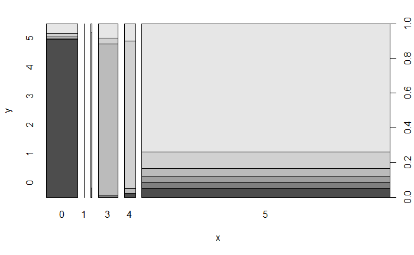

```r
# plot
plot(rf_Predg,gtestSetN$galaxysentiment)
```

```r
#calculate confusion Matrix
cmrfg <-confusionMatrix(rf_Predg,gtestSetN$galaxysentiment, mode="everything")
cmrfg
```

```
Confusion Matrix and Statistics

          Reference
Prediction    0    1    2    3    4    5
         0  354    0    3    2    9   21
         1    0    0    1    0    0    1
         2    1    0   17    0    0    1
         3    0    3    0  213    8   20
         4    3    0    0    4  118   14
         5  150  111  114  133  290 2280

Overall Statistics

               Accuracy : 0.7703
                 95% CI : (0.7568, 0.7835)
    No Information Rate : 0.6037
    P-Value [Acc > NIR] : < 2.2e-16

                  Kappa : 0.5378

 Mcnemar's Test P-Value : NA

Statistics by Class:

                     Class: 0  Class: 1 Class: 2 Class: 3 Class: 4 Class: 5
Sensitivity           0.69685 0.0000000 0.125926  0.60511  0.27765   0.9756
Specificity           0.98959 0.9994677 0.999465  0.99119  0.99391   0.4798
Pos Pred Value        0.91003 0.0000000 0.894737  0.87295  0.84892   0.7407
Neg Pred Value        0.95577 0.9705350 0.969367  0.96168  0.91774   0.9281
Precision             0.91003 0.0000000 0.894737  0.87295  0.84892   0.7407
Recall                0.69685 0.0000000 0.125926  0.60511  0.27765   0.9756
F1                    0.78930       NaN 0.220779  0.71477  0.41844   0.8421
Prevalence            0.13123 0.0294498 0.034875  0.09093  0.10979   0.6037
Detection Rate        0.09145 0.0000000 0.004392  0.05502  0.03048   0.5890
Detection Prevalence  0.10049 0.0005167 0.004908  0.06303  0.03591   0.7951
Balanced Accuracy     0.84322 0.4997338 0.562695  0.79815  0.63578   0.7277
```